# Assigment 1 Reproducible Research - abigail2105

17 April 2015

## Introduction:

It is now possible to collect a large amount of data about personal movement using activity monitoring devices such as a Fitbit, Nike Fuelband, or Jawbone Up. These type of devices are part of the “quantified self” movement - a group of enthusiasts who take measurements about themselves regularly to improve their health, to find patterns in their behavior, or because they are tech geeks. But these data remain under-utilized both because the raw data are hard to obtain and there is a lack of statistical methods and software for processing and interpreting the data.

This assignment makes use of data from a personal activity monitoring device. This device collects data at 5 minute intervals through out the day. The data consists of two months of data from an anonymous individual collected during the months of October and November, 2012 and include the number of steps taken in 5 minute intervals each day.

## Loading and preprocessing the data

The data for this assignment can be downloaded from the course web site:

```
Dataset: Activity monitoring data [52K]
https://d396qusza40orc.cloudfront.net/repdata%2Fdata%2Factivity.zip
```

The variables included in this dataset are:

```
steps: Number of steps taking in a 5-minute interval (missing values are coded as NA)

date: The date on which the measurement was taken in YYYY-MM-DD format

interval: Identifier for the 5-minute interval in which measurement was taken
```

The dataset is stored in a comma-separated-value (CSV) file with a total of 17,568 observations in this dataset. The data were downloaded to the working directory, then extracted from the zip file and loaded using the following code:

```r
temp <- unzip("activity.zip")
activity <- read.csv(temp)
class(activity)
```

```
## [1] "data.frame"
```

```r
summary(activity)
```

```
##      steps                date          interval
##  Min.   :  0.00   2012-10-01:  288   Min.   :   0.0
##  1st Qu.:  0.00   2012-10-02:  288   1st Qu.: 588.8
##  Median :  0.00   2012-10-03:  288   Median :1177.5
##  Mean   : 37.38   2012-10-04:  288   Mean   :1177.5
##  3rd Qu.: 12.00   2012-10-05:  288   3rd Qu.:1766.2
##  Max.   :806.00   2012-10-06:  288   Max.   :2355.0
##  NA's   :2304     (Other)   :15840
```

```r
days <- levels(activity$date)
no.days <- length(days)
summary(activity$date)
```

```
## 2012-10-01 2012-10-02 2012-10-03 2012-10-04 2012-10-05 2012-10-06
##        288        288        288        288        288        288
## 2012-10-07 2012-10-08 2012-10-09 2012-10-10 2012-10-11 2012-10-12
##        288        288        288        288        288        288
## 2012-10-13 2012-10-14 2012-10-15 2012-10-16 2012-10-17 2012-10-18
##        288        288        288        288        288        288
## 2012-10-19 2012-10-20 2012-10-21 2012-10-22 2012-10-23 2012-10-24
##        288        288        288        288        288        288
## 2012-10-25 2012-10-26 2012-10-27 2012-10-28 2012-10-29 2012-10-30
##        288        288        288        288        288        288
## 2012-10-31 2012-11-01 2012-11-02 2012-11-03 2012-11-04 2012-11-05
##        288        288        288        288        288        288
## 2012-11-06 2012-11-07 2012-11-08 2012-11-09 2012-11-10 2012-11-11
##        288        288        288        288        288        288
## 2012-11-12 2012-11-13 2012-11-14 2012-11-15 2012-11-16 2012-11-17
##        288        288        288        288        288        288
## 2012-11-18 2012-11-19 2012-11-20 2012-11-21 2012-11-22 2012-11-23
##        288        288        288        288        288        288
## 2012-11-24 2012-11-25 2012-11-26 2012-11-27 2012-11-28 2012-11-29
##        288        288        288        288        288        288
## 2012-11-30
##        288
```

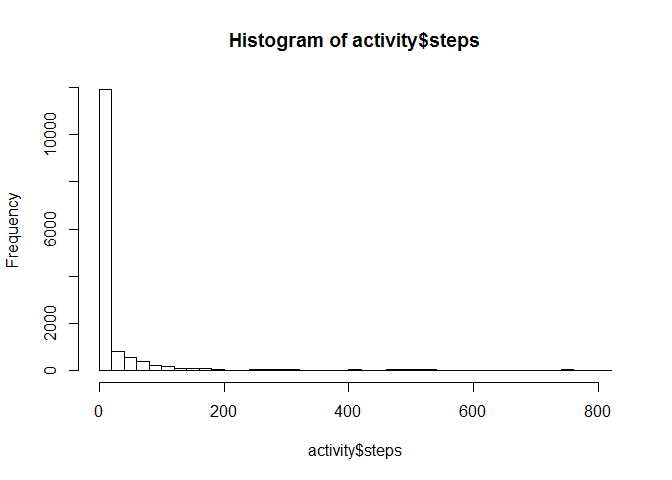

```r
hist(activity$steps, 50) # long right tail
```

We can see that the data cover 61 days, with 288 intervals of 5 minutes in each day, which adds up to 24 hours (288*5/24 = 60).

The data are in the form of a data frame, a format which is suitable for further analysis.

Steps per interval vary from 0 to 806. The step data are heavily skewed with a very long right tail.

Out of all these 17568 (61*288) intervals, 2304 are missing data (coded as NA). Before proceeding further it is necessary to adjust the data to account for or address the problem of missing data (NA values).This could be done using two approaches, both of which are applied in the following sections.

1. Remove NA values. This first approach is the simplest, as we simply remove the NA values. However this is not ideal as it results in uneven numbers of intervals, with many days not having 24 hours, and as the NAs could be at any time of day with any activity level this could result in significant bias.
2. Estimate the NA values. The second approach is more complex and is to estimate the values of the missing data based on the characteristics of the data provided in the data set. The values could be estimated in several ways, for example based on average values for the particular time of day (parameter “interval”), the day of the week (requires analysis to determine this additional parameter) or the date (parameter “date”) of each entry with missing data.